# Exploring Video Watching Habits Over Time

## Introduction

This data explores my YouTube viewing behaviour. Data was collected in two sessions which were roughly a month apart, ~20 observations were made over a period of days in both sessions. The type of data includes the time of day watched, video type, video length and reason for watching.

## Number of Videos by Type

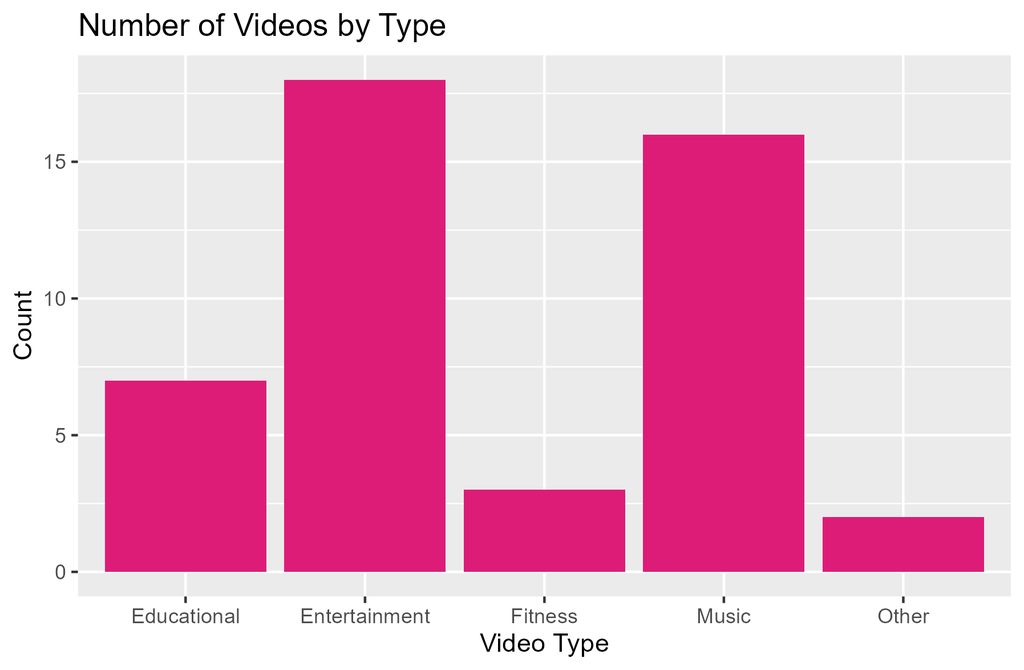

Bar chart showing number of videos by type

## Reasons for Watching Videos

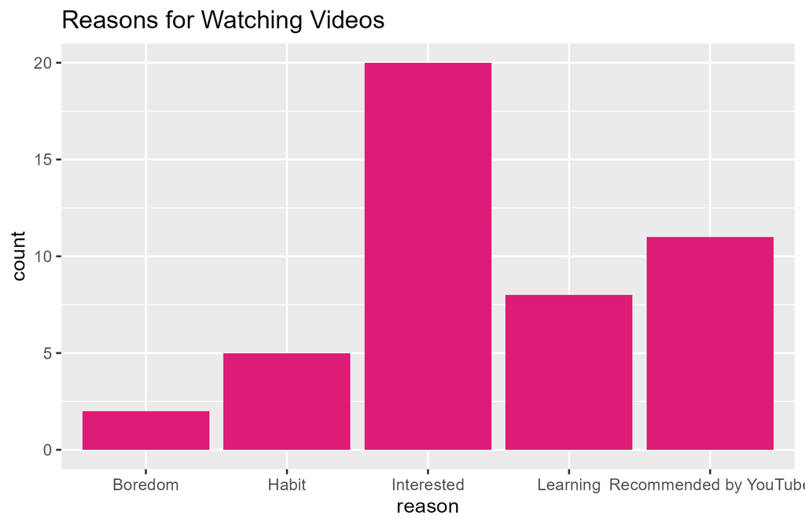

Bar chart showing reasons for watching videos

This plot shows the reasons for watching videos, with counts representing the frequency of each category. The reasons include Boredom, Habit, Interested, Learning, and Recommended by YouTube. The most common reason for watching videos is Interest, suggesting that I usually have a clear intention when selecting content. The least reported reason is Boredom, indicating that YouTube is generally used intentionally rather than as a default activity.

## Videos Watched Over time

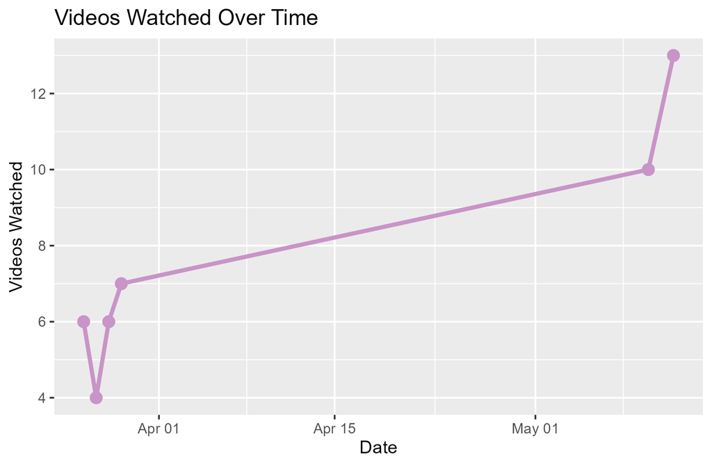

Line graph showing videos watched overtime

## Conclusion

Overall, this data shows clear patterns in my viewing habits, including consistent preferences for certain video types and reasons for watching. The timeline also highlights how my behaviour changes across different periods.